# It's Lit. An Extensive Study Of Young People

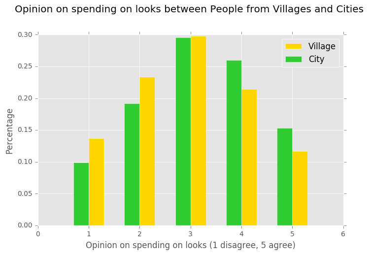

```python
ax,fig = plt.subplots(figsize = (8,5))
plt.bar(bar_locations, v_study['Spending on looks'], bar_width, color = 'gold')
plt.bar(bar_locations - bar_width, c_study['Spending on looks'], bar_width, color='limegreen')
plt.legend(["Village", "City"], loc = 'upper right')
plt.xlabel('Opinion on spending on looks (1 disagree, 5 agree)')
plt.ylabel('Percentage')
plt.title('Opinion on spending on looks between People from Villages and Cities ', y= 1.1)
plt.show()
```

To utilize the previous information, we gathered information on a young person’s preferences for purchasing branded clothing. The next figure clearly shows that the percentages are not similar for young villagers’ and young city residents’ preferences on buying clothing. More than 40% of city residents spend more on branded clothing, whereas only *34%* of villagers spend a large amount of money on branded clothing. With this new information, we can advise an advertising firm to tailor their advertisements for higher end clothing towards the population residing in cities, while also tailoring their ads for unbranded clothes towards the village population. This would drastically lower the underlying costs of mindless spending on ineffective ads, which large clothing industries often spend on.

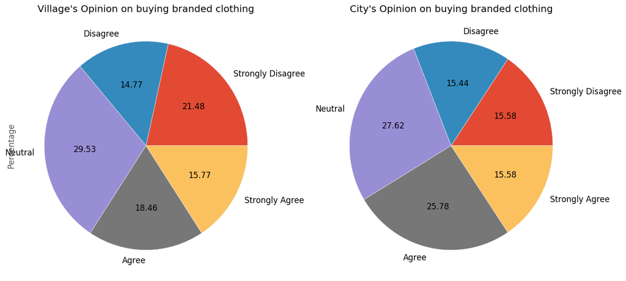

```python
plt.subplot(1,2,1)
v_study['Branded clothing'].plot.pie(labels = onefive, autopct = '%.2f', fontsize = 12, figsize = (15,7))
plt.ylabel('Percentage')
plt.title('Village\'s Opinion on buying branded clothing')
plt.subplot(1,2,2)
c_study['Branded clothing'].plot.pie(labels = onefive, autopct = '%.2f', fontsize = 12, figsize = (15,7))
plt.ylabel('')
plt.title('City\'s Opinion on buying branded clothing')
plt.show()
```

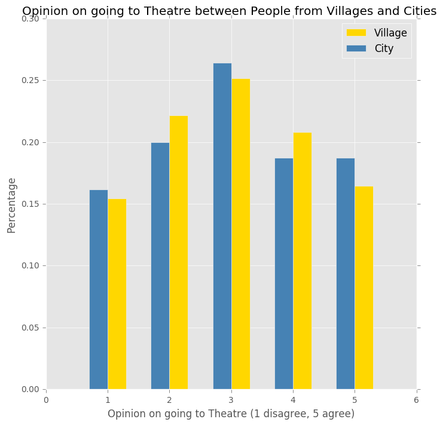

```python
plt.bar(bar_locations, v_study['Theatre'], bar_width, color = 'gold')
plt.bar(bar_locations - bar_width, c_study['Theatre'], bar_width, color='steelblue')
plt.legend(["Village", "City"], loc = 'upper right')
plt.xlabel('Opinion on going to Theatre (1 disagree, 5 agree)')
plt.ylabel('Percentage')
plt.title('Opinion on going to Theatre between People from Villages and Cities ')
plt.show()
```

Have you ever seen ads while at the movies? If you answered no, then you must be very lucky. Chances are you have been to the movie theater, and you have seen many interesting ads on the big screen. We all know the inevitability of seeing these ads before your movie comes on, and how effective they are. For the last section, we decided to see whether villagers or city residents enjoyed going to the movies more, depicted in a visual representation above. Surprisingly, the distribution of movie-going preferences are quite similar across the two demographics. This means we can advise the firm to invest on advertisements for movies theaters in both villages and cities. Consequently, companies, could perhaps cut funding proportionately by the amount of people who do not prefer going to the theaters.

# Conclusion

Data is crucial for the functions of any firm. By imitating consultants, our team was able to apply data science techniques behind a diverse dataset to find results that a firm can utilize to incentivize their spending and resource allocation towards targeting different sub-demographics of the *young people* age group. Our analysis suggested that different strategies for advertising towards a variety of demographics yields more efficient results and garner a more cost effective investment. Without the use of data and data science, a firm would surely collapse due to a lack of understanding of the market.

Slovakia is a modern nation that is growing at a heightened pace. The nation is a perfect representation of [any](https://www.weforum.org/agenda/2016/02/europe-s-10-fastest-growing-economies/) fast growing European nation such as, Ireland, Romania, and Poland. However, the importance of our research should not be limited to the confines of the European Union. In fact, our analysis can be generalized across similar demographics of different countries. [Research](http://www.economist.com/blogs/graphicdetail/2015/09/daily-chart-9) shows that consumer spending is similar across different countries from around the globe. Thus, advertising firms from other countries may see our analysis as a useful tool towards their ambitious endeavors. And who knows how lit or not lit young people may be. The fate of many busineses are at the hands of this important demographic. It would be foolish to overlook any information about the most important demographic - the young people.